# Exploring-WGBS-data

### Load libraries

```r
list.of.packages <- c("tidyverse", "reshape2", "here", "readr", "janitor", "dplyr", "scales", "ggplot2") #add new libraries here
new.packages <- list.of.packages[!(list.of.packages %in% installed.packages()[,"Package"])]
if(length(new.packages)) install.packages(new.packages)

# Load all libraries
lapply(list.of.packages, FUN = function(X) {
  do.call("require", list(X))
})
sessionInfo()
```

## Examine results from Bismark-only pipline

### Read in coverage data

**Column contents**  
1. chromosome  
2. start position  
3. end position  
4. methylation percentage  
5. count methylated  
6. count non-methylated

```r
cov.b <- read_delim(here::here("qc-processing", "bismark", "Cmagister_WGBS_S11_L003_R1_001_val_1_bismark_bt2_pe.deduplicated.bismark.cov"), delim="\t", col_names = c("contig", "start", "end", "percMeth", "meth", "unmeth"))
  # mutate_at(c("watson_meth", "watson_coverage", "watson_qual", "crick_meth", "crick_coverage", "crick_qual"),as.numeric) %>%
  # mutate_at(c("number_chrom", "context"),as.factor) %>%
  # mutate(watson_perc_meth=watson_meth/watson_coverage, crick_perc_meth=crick_meth/crick_coverage)

str(cov.b)
```

```
## tibble [23,062,040 × 6] (S3: spec_tbl_df/tbl_df/tbl/data.frame)
##  $ contig  : chr [1:23062040] "contig_1_pilon" "contig_1_pilon" "contig_1_pilon" "contig_1_pilon" ...
##  $ start   : num [1:23062040] 2229 2254 2527 2554 2559 ...
##  $ end     : num [1:23062040] 2229 2254 2527 2554 2559 ...
##  $ percMeth: num [1:23062040] 0 0 0 0 0 0 0 0 0 0 ...
##  $ meth    : num [1:23062040] 0 0 0 0 0 0 0 0 0 0 ...
##  $ unmeth  : num [1:23062040] 2 2 5 5 5 1 4 3 4 3 ...
##  - attr(*, "spec")=
##   .. cols(
##   ..   contig = col_character(),
##   ..   start = col_double(),
##   ..   end = col_double(),
##   ..   percMeth = col_double(),
##   ..   meth = col_double(),
##   ..   unmeth = col_double()
##   .. )
```

### Add coverage column and estimate of “methylated” and “unmethylated” based on 50% threshold

```r
cov.b <- cov.b %>%
  mutate(coverage=meth+unmeth) %>%
  mutate(methyl.status=factor(ifelse(percMeth >= 50, 'methylated', "unmethylated")))
```

```r
cov.b.10x <- subset(cov.b, coverage>9)
cov.b.5x <- subset(cov.b, coverage>4)

subset(cov.b, contig=="contig_2928_pilon" & start==7) #check to make sure only 1 row per contig+locus
```

```
## # A tibble: 1 x 8
##   contig            start   end percMeth  meth unmeth coverage methyl.status
##   <chr>             <dbl> <dbl>    <dbl> <dbl>  <dbl>    <dbl> <fct>
## 1 contig_2928_pilon     7     7      0.5     1    199      200 unmethylated
```

### Read in the methylation call file to see if it contains a “call” for each locus, or for each read

Answer: this file containsmethylation calls for each sequenced read, not for each locus.

```r
# meth.b <- read_delim(here::here("qc-processing", "bismark", "CpG_context_Cmagister_WGBS_S11_L003_R1_001_val_1_bismark_bt2_pe.deduplicated.txt"), delim="\t", col_names = c("seqID", "meth.state", "chrom", "pos", "methcall"))
# head(meth.b)
#
# subset(meth.b, chrom=="contig_2928_pilon" & pos==7) #how many rows atthis locus? Answer = 200. So, this file contain methylation calls for each read
```

### What is the mean proportion methylation?

```r
paste("Average proportion CpG methylation, no coverage limit:", percent(mean(cov.b$percMeth, na.rm = TRUE)/100, accuracy = .01))
```

```
## [1] "Average proportion CpG methylation, no coverage limit: 7.29%"
```

```r
paste("Average proportion CpG methylation, min. coverage = 5x: ", round((cov.b %>% filter(coverage>4) %>% summarize_at("percMeth", mean, na.rm=TRUE))$percMeth,digits=2), "%", sep="")
```

```
## [1] "Average proportion CpG methylation, min. coverage = 5x: 7.46%"
```

```r
paste("Average proportion CpG methylation, min. coverage = 10x: ", round((cov.b %>% filter(coverage>9) %>% summarize_at("percMeth", mean, na.rm=TRUE))$percMeth,digits=2), "%", sep="")
```

```
## [1] "Average proportion CpG methylation, min. coverage = 10x: 7.83%"
```

### What is the overall percent of loci that are methylated (percMeth >50%)?

```r
print("Mean % of loci that are methylated, no coverage limit:")
```

```
## [1] "Mean % of loci that are methylated, no coverage limit:"
```

```r
100*round(prop.table(table(cov.b$methyl.status)), digits=4)
```

```
##
##   methylated unmethylated
##         7.11        92.89
```

```r
print("Mean % of loci that are methylated, 5x coverage minimum:")
```

```
## [1] "Mean % of loci that are methylated, 5x coverage minimum:"
```

```r
100*round(prop.table(table(subset(cov.b, coverage>4)$methyl.status)), digits=4)
```

```
##
##   methylated unmethylated
##         6.87        93.13
```

```r
print("Mean % of loci that are methylated, 10x coverage minimum:")
```

```
## [1] "Mean % of loci that are methylated, 10x coverage minimum:"
```

```r
100*round(prop.table(table(subset(cov.b, coverage>9)$methyl.status)), digits=4)
```

```
##
##   methylated unmethylated
##         7.32        92.68
```

### How many loci remain after various degrees of filtering for coverage?

```r
paste("Total no. loci, no coverage limit:", cov.b %>% nrow())
```

```
## [1] "Total no. loci, no coverage limit: 23062040"
```

```r
paste("Total no. METHYLATED loci, no coverage limit:",cov.b %>% filter(methyl.status=="methylated") %>% nrow())
```

```
## [1] "Total no. METHYLATED loci, no coverage limit: 1639640"
```

```r
paste("Total no. UNMETHYLATED loci, no coverage limit:",cov.b %>% filter(methyl.status=="unmethylated") %>% nrow())
```

```
## [1] "Total no. UNMETHYLATED loci, no coverage limit: 21422400"
```

```r
paste("Total no. loci, 5x coverage min:", cov.b %>% filter(coverage>4) %>% nrow())
```

```
## [1] "Total no. loci, 5x coverage min: 14834165"
```

```r
paste("Total no. METHYLATED loci, 5x coverage min:", cov.b %>% filter(methyl.status=="methylated" & coverage>4) %>% nrow())
```

```
## [1] "Total no. METHYLATED loci, 5x coverage min: 1018814"
```

```r
paste("Total no. UNMETHYLATED loci, 5x coverage min:", cov.b %>% filter(methyl.status=="unmethylated" & coverage>4) %>% nrow())
```

```
## [1] "Total no. UNMETHYLATED loci, 5x coverage min: 13815351"
```

```r
paste("Total no. loci, 10x coverage min:", cov.b %>% filter(coverage>9) %>% nrow())
```

```
## [1] "Total no. loci, 10x coverage min: 9820981"
```

```r
paste("Total no. METHYLATED loci, 10x coverage min:", cov.b %>% filter(methyl.status=="methylated" & coverage>9) %>% nrow())
```

```
## [1] "Total no. METHYLATED loci, 10x coverage min: 718877"
```

```r
paste("Total no. UNMETHYLATED loci, 10x coverage min:", cov.b %>% filter(methyl.status=="unmethylated" & coverage>9) %>% nrow())
```

```
## [1] "Total no. UNMETHYLATED loci, 10x coverage min: 9102104"
```

### CpG methylation bias by position

Check out methylation bias by position. Note: the txt file that contains bias data has info for all cytosine contexts; the first 134 rows represent data for CpG context (which is why I only keep rows 4-134).

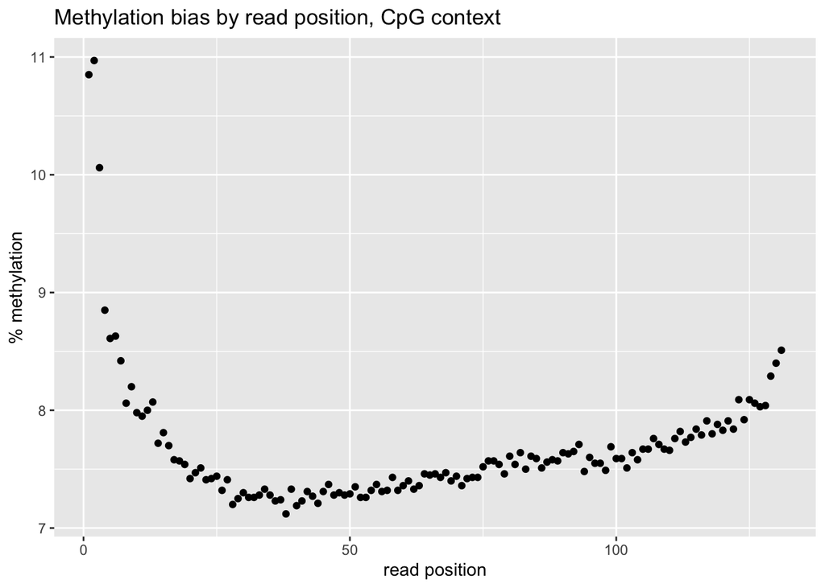

```r
read_delim(here::here("qc-processing", "bismark", "Cmagister_WGBS_S11_L003_R1_001_val_1_bismark_bt2_pe.deduplicated.M-bias.txt"),
                      delim="\t", col_names = c("read.pos", "n.meth", "n.unmeth", "perc.meth", "cov")) [4:134,] %>%
  mutate_if(is.character,as.numeric) %>%
  ggplot(aes(x=read.pos, y=perc.meth)) + geom_point() + ggtitle("Methylation bias by read position, CpG context") +
  xlab("read position") + ylab("% methylation")
```

## Additional stats, not reported in the Methods/Results paragraphs

NOTE: The below works with the data file “cov2cyto.CpG_report.merged_CpG_evidence.cov” that was created using the `coverage2cytosine` function in Bismark. I believe this function reports coverage and methylation data for ALL CpG loci in the genome, not just for those for which we have data. Not sure how this is useful for understanding global methylation rate, but the MethCompare pipeline included this stip, so I process the data here in case we deem it necessary down the line.

### Generage summary stats from merged coverage file (top and bottom strand info merged)

```r
mergecov.b <- read_delim(here::here("qc-processing", "bismark", "cov2cyto.CpG_report.merged_CpG_evidence.cov"), delim="\t", col_names = c("contig", "start", "stop", "perc.meth", "meth", "unmeth"))
```

### Add coverage column and estimate of “methylated” and “unmethylated” based on 50% threshold

```r
mergecov.b <- mergecov.b %>%
  mutate(coverage=meth+unmeth) %>%
  mutate(methyl.status=factor(ifelse(perc.meth >= 50, 'methylated', "unmethylated")))
```

```r
mergecov.b.10x <- subset(mergecov.b, coverage>9)
mergecov.b.5x <- subset(mergecov.b, coverage>4)
```

### What is the mean proportion methylation?

```r
paste("Average proportion CpG methylation, no coverage limit:", percent(mean(mergecov.b$perc.meth, na.rm = TRUE)/100, accuracy = .01))
```

```
## [1] "Average proportion CpG methylation, no coverage limit: 6.89%"
```

```r
paste("Average proportion CpG methylation, min. coverage = 5x: ", round((mergecov.b %>% filter(coverage>4) %>% summarize_at("perc.meth", mean, na.rm=TRUE))$perc.meth,digits=2), "%", sep="")
```

```
## [1] "Average proportion CpG methylation, min. coverage = 5x: 7.1%"
```

```r
paste("Average proportion CpG methylation, min. coverage = 10x: ", round((mergecov.b %>% filter(coverage>9) %>% summarize_at("perc.meth", mean, na.rm=TRUE))$perc.meth,digits=2), "%", sep="")
```

```
## [1] "Average proportion CpG methylation, min. coverage = 10x: 7.47%"
```

### What is the overall percent of loci that are methylated (perc.meth >50%)?

```r
print("Mean % of loci that are methylated, no coverage limit:")
```

```
## [1] "Mean % of loci that are methylated, no coverage limit:"
```

```r
100*round(prop.table(table(mergecov.b$methyl.status)), digits=4)
```

```
##
##   methylated unmethylated
##         6.29        93.71
```

```r
print("Mean % of loci that are methylated, 5x coverage minimum:")
```

```
## [1] "Mean % of loci that are methylated, 5x coverage minimum:"
```

```r
100*round(prop.table(table(subset(mergecov.b, coverage>4)$methyl.status)), digits=4)
```

```
##
##   methylated unmethylated
##         6.26        93.74
```

```r
print("Mean % of loci that are methylated, 10x coverage minimum:")
```

```
## [1] "Mean % of loci that are methylated, 10x coverage minimum:"
```

```r
100*round(prop.table(table(subset(mergecov.b, coverage>9)$methyl.status)), digits=4)
```

```
##
##   methylated unmethylated
##         6.75        93.25
```

```r
paste("Total no. loci, no coverage limit:", mergecov.b %>% nrow())
```

```
## [1] "Total no. loci, no coverage limit: 13476106"
```

```r
paste("Total no. METHYLATED loci, no coverage limit:",mergecov.b %>% filter(methyl.status=="methylated") %>% nrow())
```

```
## [1] "Total no. METHYLATED loci, no coverage limit: 847972"
```

```r
paste("Total no. UNMETHYLATED loci, no coverage limit:",mergecov.b %>% filter(methyl.status=="unmethylated") %>% nrow())
```

```
## [1] "Total no. UNMETHYLATED loci, no coverage limit: 12628134"
```

```r
paste("Total no. loci, 5x coverage min:", mergecov.b %>% filter(coverage>4) %>% nrow())
```

```
## [1] "Total no. loci, 5x coverage min: 11094875"
```

```r
paste("Total no. METHYLATED loci, 5x coverage min:", mergecov.b %>% filter(methyl.status=="methylated" & coverage>4) %>% nrow())
```

```
## [1] "Total no. METHYLATED loci, 5x coverage min: 694618"
```

```r
paste("Total no. UNMETHYLATED loci, 5x coverage min:", mergecov.b %>% filter(methyl.status=="unmethylated" & coverage>4) %>% nrow())
```

```
## [1] "Total no. UNMETHYLATED loci, 5x coverage min: 10400257"
```

```r
paste("Total no. loci, 10x coverage min:", mergecov.b %>% filter(coverage>9) %>% nrow())
```

```
## [1] "Total no. loci, 10x coverage min: 8869155"
```

```r
paste("Total no. METHYLATED loci, 10x coverage min:", mergecov.b %>% filter(methyl.status=="methylated" & coverage>9) %>% nrow())
```

```
## [1] "Total no. METHYLATED loci, 10x coverage min: 598953"
```

```r
paste("Total no. UNMETHYLATED loci, 10x coverage min:", mergecov.b %>% filter(methyl.status=="unmethylated" & coverage>9) %>% nrow())
```

```
## [1] "Total no. UNMETHYLATED loci, 10x coverage min: 8270202"
```

## Examine results from the MethylExtract pipeline - no longer needed, decided to use Bismark tools isntead

Import methylation tab file

```r
meth <- read_delim(here::here("qc-processing", "methylExtract", "CG.output"), delim="\t", col_names = TRUE) %>%
  clean_names() %>%
  mutate_at(c("watson_meth", "watson_coverage", "watson_qual", "crick_meth", "crick_coverage", "crick_qual"),as.numeric) %>%
  mutate_at(c("number_chrom", "context"),as.factor) %>%
  mutate(watson_perc_meth=watson_meth/watson_coverage, crick_perc_meth=crick_meth/crick_coverage)
```

### Call methylation status based on % methylation

A locus is methylated if 50% or greater reads are methylated, that is they were unconverted after bisulfite treatment (in this dataset they are “C’s”) (Gavery and Roberts 2013; Olson and Roberts 2013). I will therefore determine methylation status using the numCs/coverage, where methylated = any greater or equal to 50%.

```r
meth <- meth %>%
  mutate(watson_methstatus=factor(ifelse(watson_perc_meth >= 0.5, 'methylated', "unmethylated")),
         crick_methstatus=factor(ifelse(crick_perc_meth >= 0.5, 'methylated', "unmethylated")))
```

## Inspect Context column

The context column contains info regarding SNVs, using the bellow IUPAC nucleotide codes, pulled from https://www.bioinformatics.org/sms/iupac.html.

| IUPAC nucleotide code | Base |
| --- | --- |
| A | Adenine |
| C | Cytosine |
| G | Guanine |
| T (or U) | Thymine (or Uracil) |
| R | A or G |
| Y | C or T |
| S | G or C |
| W | A or T |
| K | G or T |
| M | A or C |
| B | C or G or T |
| D | A or G or T |
| H | A or C or T |
| V | A or C or G |
| N | any base |
| . or - | gap |

```r
table(meth$context)
```

```
##
##       CG       CK       CR       CS       MG       MK       MR       MS
## 13144941    10123   267541     6532    10173      583     1632      461
##       SG       SK       SR       SS       YG       YK       YR       YS
##     6463      477      678      405   270547     1545     7818      732
```

```r
loci_context <- as.data.frame(table(meth$context))
paste("% of loci with CG context:", percent(loci_context[loci_context$Var1=="CG", "Freq"]/sum(loci_context$Freq), accuracy = 0.01))
```

```
## [1] "% of loci with CG context: 95.73%"
```

## Calculate % of all CpG loci that are methylated.

NOTE: for all summary stats I will only use data at CG contexts

```r
# FWD
prop.table(table(subset(meth, context=="CG")$watson_methstatus))
```

```
##
##   methylated unmethylated
##   0.06790111   0.93209889
```

```r
# REV
prop.table(table(subset(meth, context=="CG")$crick_methstatus))
```

```
##
##   methylated unmethylated
##   0.06809196   0.93190804
```

## Average coverage and proportion of CpG methylation on Forward (watson) and Reverse (crick) strands

```r
paste("Average proportion CpG methylation, FWD:", percent(mean(subset(meth, context=="CG")$watson_perc_meth, na.rm=T), accuracy = .01))
```

```
## [1] "Average proportion CpG methylation, FWD: 7.01%"
```

```r
paste("Average coverage, FWD:", round(mean(subset(meth, context=="CG")$watson_coverage, na.rm=T), digits = 0))
```

```
## [1] "Average coverage, FWD: 21"
```

```r
paste("Average proportion CpG methylation, REV:", percent(mean(subset(meth, context=="CG")$crick_perc_meth, na.rm=T), accuracy = .01))
```

```
## [1] "Average proportion CpG methylation, REV: 7.05%"
```

```r
paste("Average coverage, REV:", round(mean(subset(meth, context=="CG")$crick_coverage, na.rm=T), digits = 0))
```

```
## [1] "Average coverage, REV: 21"
```

## Repeat the above, but for loci with 5x coverage only

```r
paste("No. of FWD loci in dataset:", prettyNum(length(na.omit(subset(meth, context=="CG")$watson_coverage)), big.mark = ","))
```

```
## [1] "No. of FWD loci in dataset: 10,863,828"
```

```r
paste("No. of FWD loci with 5x coverage or greater:", prettyNum(nrow(subset(meth, watson_coverage>4 & context=="CG")), big.mark = ","))
```

```
## [1] "No. of FWD loci with 5x coverage or greater: 7,952,477"
```

```r
paste("Average proportion CpG methylation (5x cov), FWD:", percent(mean(subset(meth, watson_coverage>4 & context=="CG")$watson_perc_meth, na.rm=T), accuracy = .01))
```

```
## [1] "Average proportion CpG methylation (5x cov), FWD: 7.21%"
```

```r
paste("No. of REV loci in dataset:", prettyNum(length(na.omit(subset(meth, context=="CG")$crick_coverage)), big.mark = ","))
```

```
## [1] "No. of REV loci in dataset: 10,850,282"
```

```r
paste("No. of REV loci with 5x coverage or greater:", prettyNum(nrow(subset(meth, crick_coverage>4 & context=="CG")), big.mark = ","))
```

```
## [1] "No. of REV loci with 5x coverage or greater: 7,943,381"
```

```r
paste("Average proportion CpG methylation (5x cov), REV:", percent(mean(subset(meth, crick_coverage>4 & context=="CG")$crick_perc_meth, na.rm=T), accuracy = .01))
```

```
## [1] "Average proportion CpG methylation (5x cov), REV: 7.24%"
```